# Отчёт по лабораторной работе №3.

Mathematics Typing

Коне Сирики

Российский университет дружбы народов, Москва, Россия

Объединённый институт ядерных исследований, Дубна, Россия

08 Октября 2025

# Информация

## Докладчик

- Коне Сирики
- Студент физмат
- профессор кафедры прикладной информатики и теории вероятностей
- Российский университет дружбы народов
- konesirisil@yandex.ru
- https://github.com/skone19

## Цель работы

Целью данной лабораторной работы является ознакомление с основами набора математических выражений в LaTeX.

The purpose of this lab work is to learn how to typeset mathematical formulas and equations using LaTeX math mode and related packages.

## Задание

1. Study inline and display math modes.
2. Use the `amsmath` package to align and format equations.
3. Apply different math fonts.
4. Use `mathtools` for advanced formatting.
5. Try bold math and Unicode math.
6. Perform the exercises with examples.

# Теоретическое введение

## 3.1 Математический режим / Math mode

В LaTeX существует два математических режима: **inline** и **display**.  
In LaTeX there are two main math modes: inline (within text) and display (centered block).

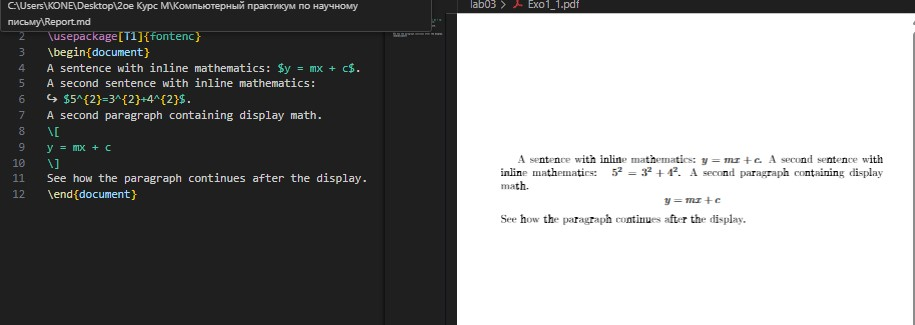

## 3.1.1 Inline math mode and mathematical notation

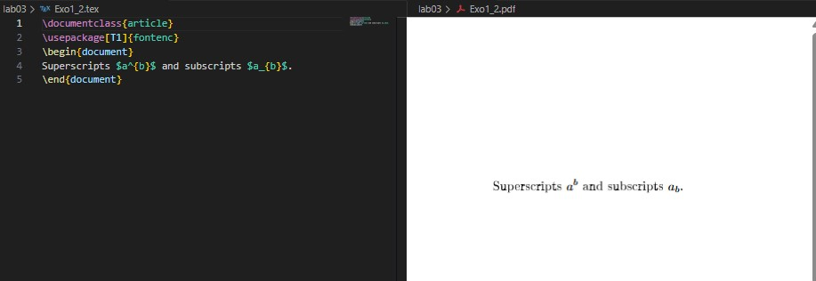

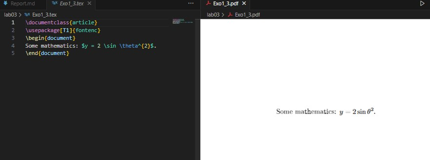

## 3.1.2 Display mathematics

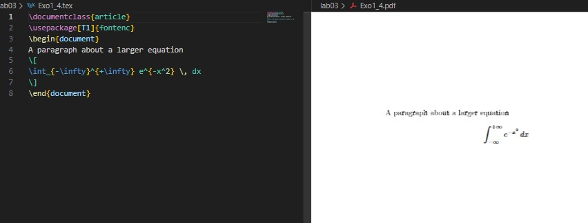

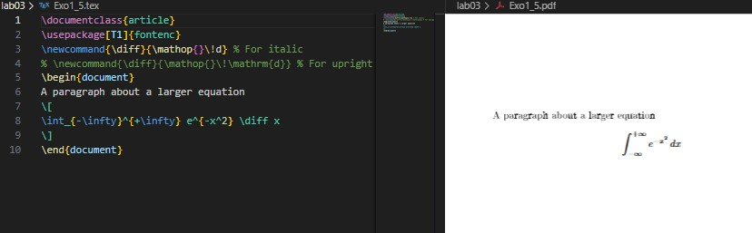

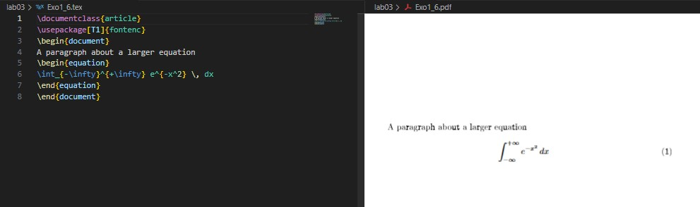

## 3.2 Пакет amsmath / The amsmath package

Пакет `amsmath` расширяет стандартные возможности для набора формул и выравнивания уравнений. The `amsmath` package enhances math typesetting and alignment.

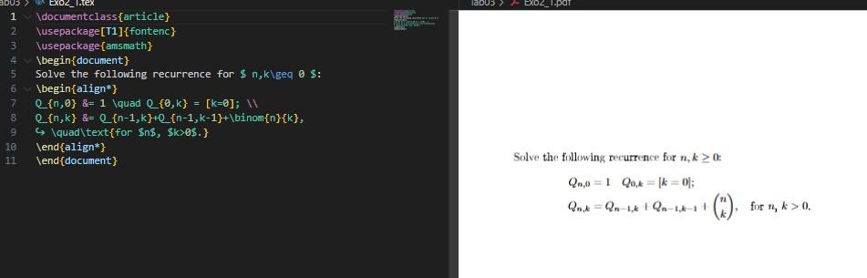

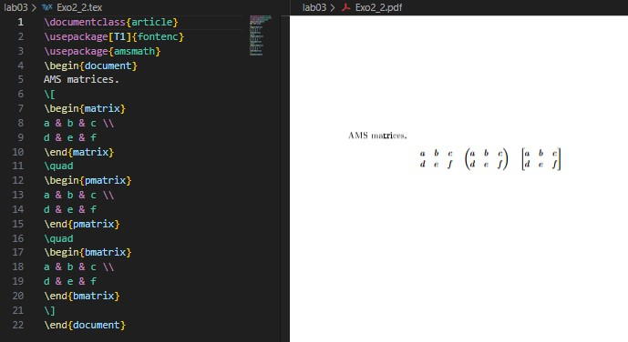

## 3.3 Шрифты в математическом режиме / Fonts in math mode

В математике разные шрифты обозначают разные типы объектов. Different font commands give different styles and meanings.

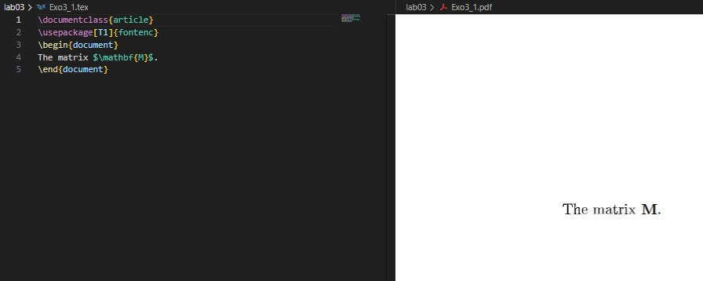

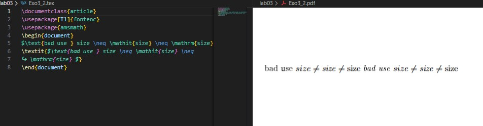

## 3.4 Дополнительные выравнивания / Further amsmath alignments

Environments like `gather` and `multline` are used for multi-line equations.

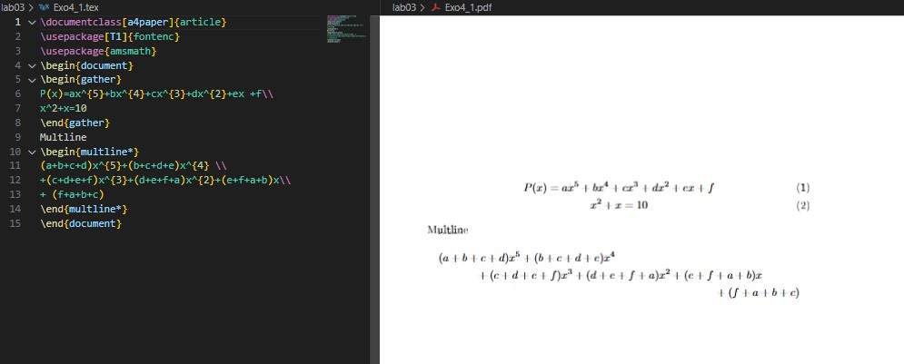

## 3.4.1 Columns in math alignments

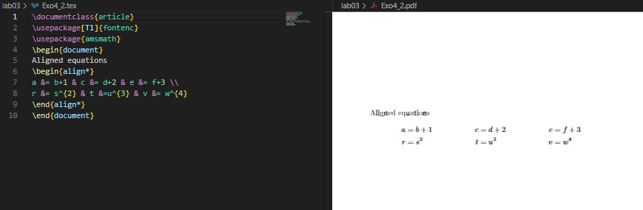

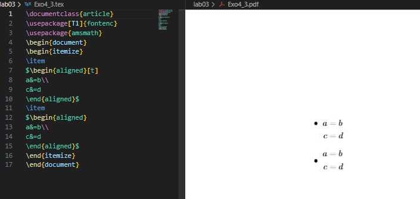

## 3.5 Жирный шрифт в формулах / Bold Math

To bold entire or partial equations, we can use `\boldmath` or the `bm` package.

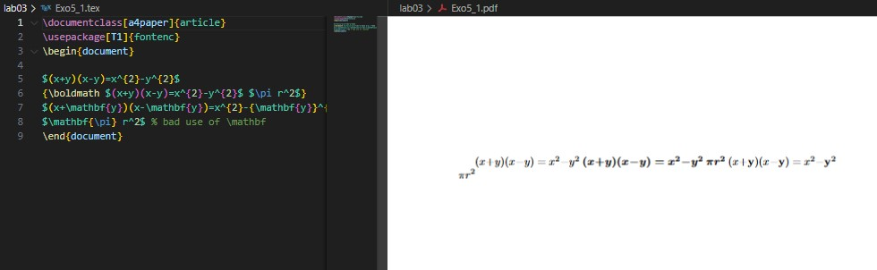

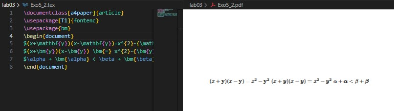

## 3.6 Пакет Mathtools / Mathtools package

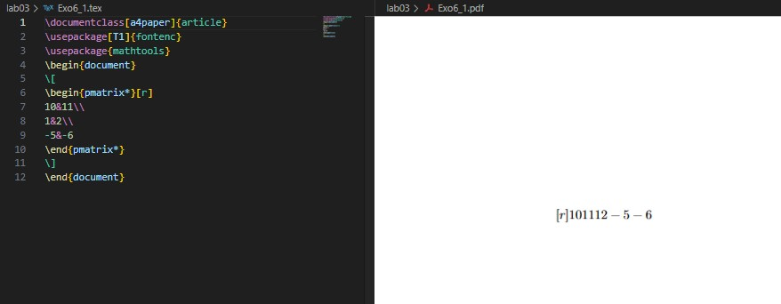

## 3.7 Юникодная математика / Unicode Math

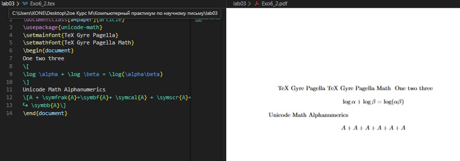

# Выполнение лабораторной работы

## 1. Переключение между режимами / Switching between math modes

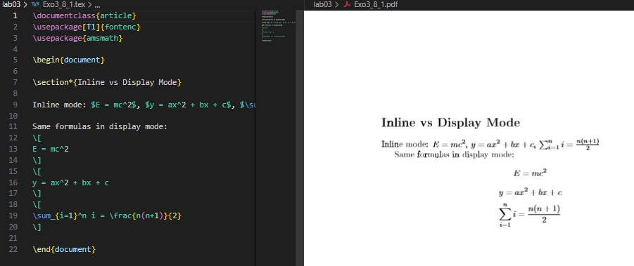

## 2. Греческие буквы / Greek letters

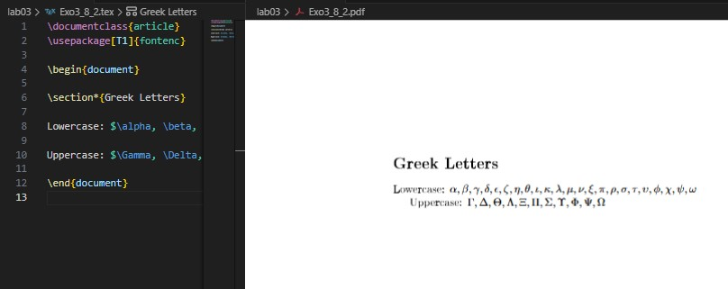

## 3. Комбинирование шрифтов / Combining fonts

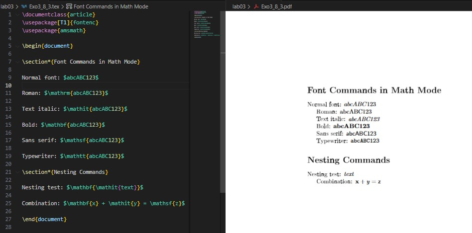